# PSY260 - Research Methods and Analysis

R Workshop 3 - Analysing Data in R

Dr Glenn Williams

2021-10-27 (Updated 2021-10-27)

Here, we’ll get used to performing analyses and summarising data in R. This set of questions introduces some more advanced functions for analysing data. These exercises are more introductory while the questions are intended to be more difficult to help test your knowledge.

# Exercises

Please run the following code chunk before getting started. This will load the 2 crucial packages for this workshop and the raw data we will use to entrench the concepts taught in the lecture.

```r
# load packages
library(tidyverse)
library(here)

# load data
raw_data <- read_csv(here("data", "seminar_three_data.csv"))
```

## Exercise 1

How many participants do we have in the experiment? How many items? Write some R code to check this.

*Hint*: `length()` and `unique()` are useful here.

```r
raw_data %>%
  summarise(
    n_subj = length(unique(subj_id)),
    n_items = length(unique(item_id))
  )
```

```
## # A tibble: 1 x 2
##   n_subj n_items
##    <int>   <int>
## 1     60      40
```

## Exercise 2

The labels for the conditions in column A are not very informative. Please give these suitable names in the data set.

There are (at least) two methods to achieve this. Create a column (or overwrite the existing one) using:

1. `case_when()` as in previous lectures/seminars.
2. `factor()` within `mutate()`.

*Please see the lecture on manipulating data if you get stuck.*

```r
# option 1: case_when in mutate
raw_data <- raw_data %>%
  mutate(
    A = case_when(
      A == "A1" ~ "congruent",
      A == "A2" ~ "incongruent"
    )
  )
```

```r
# option 2: change to a factor
raw_data$A <- factor(
  raw_data$A,
  levels = c("A1", "A2"),
  labels = c("congruent", "incongruent")
)
```

## Exercise 3

### Part A

Create a summary of the reaction times per condition for each participant. Choose a way to summarise this based on central tendency (e.g. mean, median, mode).

Typically we use this data for inferential tests and plots.

Assign this data to the object `data_summary`.

```r
data_summary <- raw_data %>%
  group_by(subj_id, A) %>%
  summarise(mean_y = mean(Y))
```

### Part B

Write a sentence to justify your choice of measure for central tendency and dispersion in your summary statistics.

*I chose the mean as it’s the most common summary, but I really should have a look at how many extreme scores I have before I do this. I also picked the mean because I simulated the data to be drawn from a normal distribution…"*

## Exercise 4

Create a plot to display the average reaction time per condition in the experiment using the data from `data_summary` in Exercise 3. Justify your choice of plot.

Assign this plot to a variable called `my_plot`.

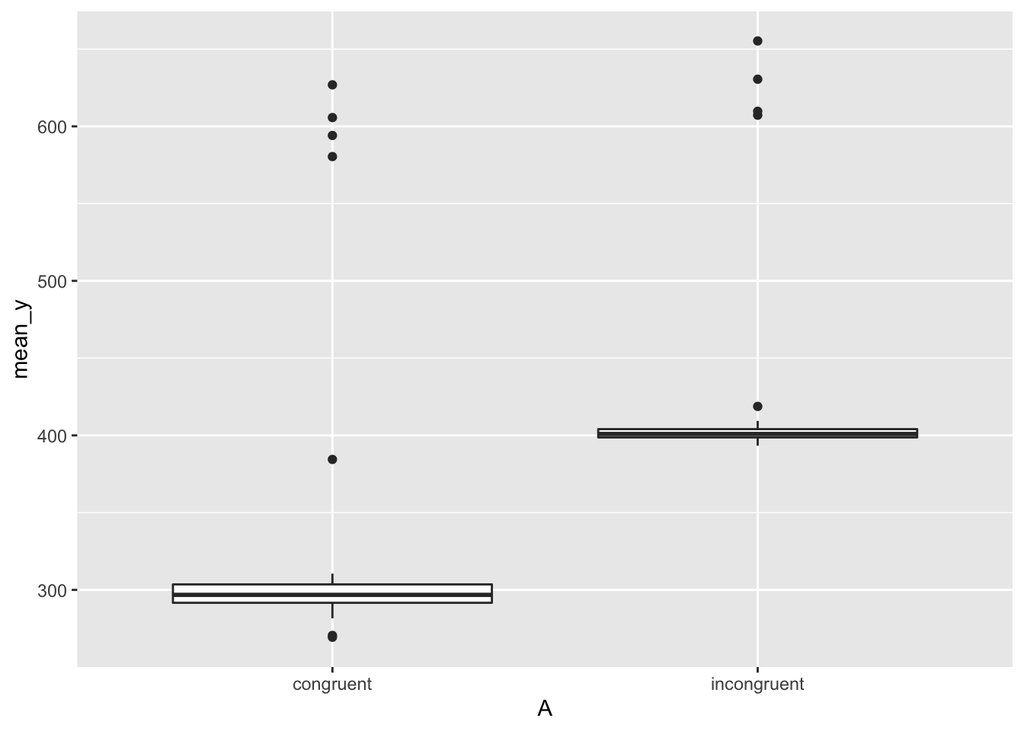

```r
my_plot <- ggplot(
  data = data_summary,
  mapping = aes(x = A, y = mean_y)
) +
  geom_boxplot()

my_plot
```

*I used the boxplot because it gives a robust measure of the average and highlights outliers.*

## Exercise 5

Update your code used to plot `my_plot` in Exercise 4 to have different fills for each condition and to have proper labels on the X and Y axis titles.

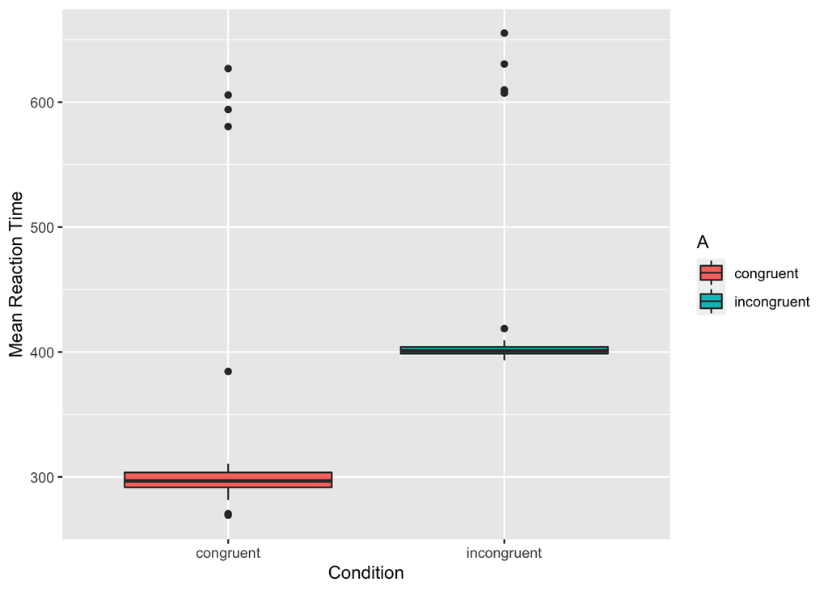

```r
my_plot <- ggplot(
  data = data_summary,
  mapping = aes(x = A, y = mean_y, fill = A)
) +
  geom_boxplot() +
  labs(x = "Condition", y = "Mean Reaction Time")

my_plot
```

## Exercise 6

In this experiment we want to exclude participants with average scores two standard deviations above or below the mean.

### Part A

Find out the overall mean and standard deviation from the reaction times saved in `data_summary`. Assign this summary to the variable `data_cutoffs`.

*Hint*: If you use `summarise()` (which you may not need to), be sure to use ungroup in your chain of functions first, e.g.: `data_summary %>% ungroup() %>% **your code goes here**`.

```r
data_cutoffs <- data_summary %>%
  ungroup() %>%
  summarise(
    mean = mean(mean_y),
    sd = sd(mean_y)
  )
data_cutoffs
```

```
## # A tibble: 1 x 2
##    mean    sd
##   <dbl> <dbl>
## 1  367.  84.2
```

### Part B

Assign this data to the object `data_summary_filtered`.

*Hint*: You will need to use your answer from Part A to achieve this.

First, assign the lower and upper bounds for outliers.

```r
outlier_low <- data_cutoffs$mean - data_cutoffs$sd*2
outlier_high <- data_cutoffs$mean + data_cutoffs$sd*2
```

Then filter out low and high scoring values in the original data.

*Hint: <, > and | operators are useful here when combined with filter().*

```r
outliers <- data_summary %>%
  filter(mean_y < outlier_low | mean_y > outlier_high)
```

Finally, remove any participant IDs who have outliers from your original data. Assign this to the object “data_summary_filtered”.

```r
data_summary_filtered <- data_summary %>%
  filter(!subj_id %in% outliers$subj_id)
```

### Part C

Create a final plot as in Exercise 5, now with your data from `data_summary_filtered`.

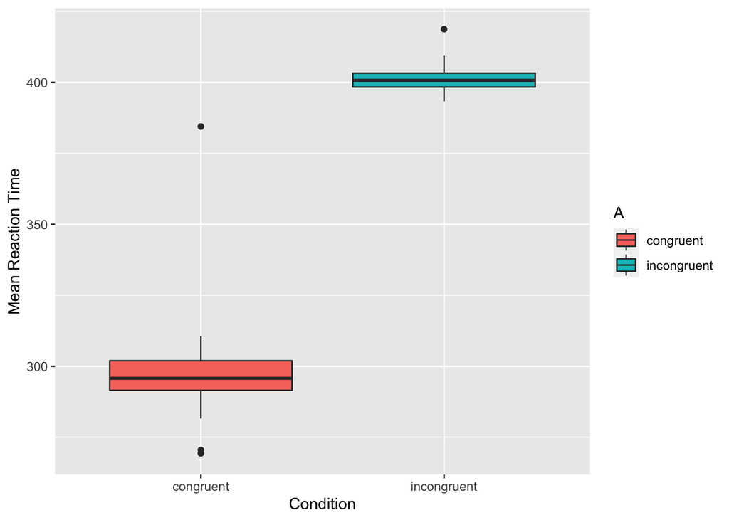

```r
ggplot(
  data = data_summary_filtered,
  mapping = aes(x = A, y = mean_y, fill = A)
) +
  geom_boxplot() +
  labs(x = "Condition", y = "Mean Reaction Time")
```

```r
# if they're really good they'll do this
# (and probably don't need a beginner's R course)
my_plot %+% data_summary_filtered
```

## Exercise 7

Taking your data from Exercise 6, conduct an appropriate statistical test to compare the mean scores for the congruent and incongruent conditions. Is there a significant difference between the groups?

Remember to use the formula interface `outcome ~ predictor`. This means scores to the left of the `~` are predicted by the values assigned to the right side of the `~`; i.e. your condition dictates your score.

```r
t.test(mean_y ~ A, data_summary_filtered, paired = TRUE)
```

```
##
##  Paired t-test
##
## data:  mean_y by A
## t = -64.084, df = 55, p-value < 2.2e-16
## alternative hypothesis: true difference in means is not equal to 0
## 95 percent confidence interval:
##  -107.3000 -100.7925
## sample estimates:
## mean of the differences
##               -104.0462
```

*Yes, there is a significant difference between the groups.*

# Questions

These remaining questions are designed to push you a little further to improve your knowledge. Please complete these in your own time.

Please run the following R code chunk by pressing the green play button. This will load the data up from the “data” folder and print it out in your console.

```r
qdata <- read_csv(here("data", "cleanish_data.csv"))
qdata # inspect it
```

```
## # A tibble: 2,400 x 7
##       X1 subj_id list_id item_id A     B         Y
##    <dbl>   <dbl>   <dbl>   <dbl> <chr> <chr> <dbl>
##  1     1       1       4       1 a2    b2     234.
##  2     2       1       4       2 a2    b2     295.
##  3     3       1       4       3 a2    b2     285.
##  4     4       1       4       4 a2    b2     258.
##  5     5       1       4       5 a2    b2     268.
##  6     6       1       4       6 a2    b2     282.
##  7     7       1       4       7 a2    b2     281.
##  8     8       1       4       8 a2    b2     291.
##  9     9       1       4       9 a2    b2     292.
## 10    10       1       4      10 a2    b2     243.
## # … with 2,390 more rows
```

This data set is that from lecture 2b - Data Checking in R. The columns have the following interpretation:

- **X1** = Row number for the data.
- **subj_id** = Subject/participant ID for the person who gave the data to us.
- **list_id** = list ID for how items were randomised.
- **item_id** = Item ID.
- **variable A** = Implied sentence location (upwards or downwards); e.g. “the bird flew in the sky.” a1 is up, a2 is down.
- **variable B** = Location of target (up or down on the screen). b1 is up, b2 is down.

## Question 1

Remove any unnecessary columns from this data set.

```r
qdata <- qdata %>% select(-X1)
```

## Question 2

Give proper levels names to the levels A1 and A2 in column A and to B1 and B2 in column B.

```r
qdata <- qdata %>%
  mutate(
    A = case_when(
      A == "a1" ~ "up",
      A == "a2" ~ "down"
    ),
    B = case_when(
      B == "b1" ~ "up",
      B == "b2" ~ "down"
    )
  )
```

## Question 3

Give proper (column) names to the variables A, B, and Y.

```r
qdata <- qdata %>%
  rename(
    sentence_location = A,
    target_location = B,
    reaction_time = Y
  )
```

## Question 4

Make a summary of the data creating averages of the reaction times for each level of each condition for every participant. Assign this to the object `summary_data`.

```r
summary_data <- qdata %>%
  group_by(subj_id, sentence_location, target_location) %>%
  summarise(mean_rt = mean(reaction_time, na.rm = TRUE))
```

## Question 5

Remove participants 1 through to 10 from `summary_data`.

```r
summary_data <- summary_data %>%
  filter(subj_id > 10)
```

## Question 6

Make a boxplot of the data. Does there appear to be any reliable differences between conditions? Explain your logic.

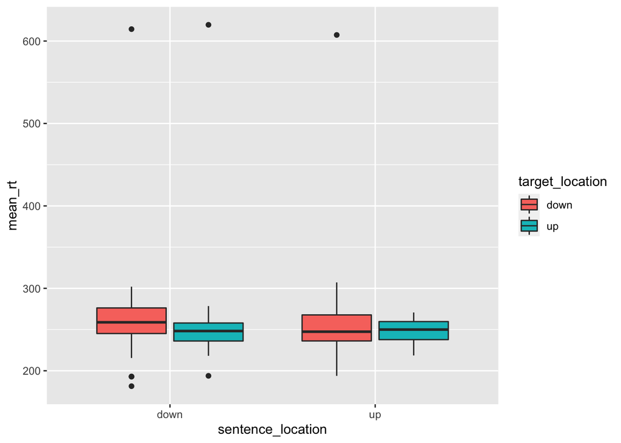

```r
ggplot(
  data = summary_data,
  mapping = aes(
    x = sentence_location,
    y = mean_rt,
    fill = target_location
  )
) +
  geom_boxplot()
```

## Question 7

We can perform inferential statistics in R.

I have simulated some data below for a one-variable, 3-group experiment. The three groups are “control”, “treatment_low”, and “treatment_high” which are assigned to the column “condition” while the outcome is in the column “outcome”. (It doesn’t matter what this column or study represents, data only have meaning we assign to it.)

```r
set.seed(1892)
n <- 60

simdat <- tibble(
  condition = c(
    rep("control", n),
    rep("treatment_low", n),
    rep("treatment_high", n)
  ),
  outcome = c(
    rnorm(n, mean = 100, sd = 15),
    rnorm(n, mean = 105, sd = 16),
    rnorm(n, mean = 124, sd = 12)
  )
)
```

Analyse this data using an appropraite ANOVA method. Report the results below.

```r
sim_aov <- aov(outcome ~ condition, simdat)
summary(sim_aov)
```

```
##              Df Sum Sq Mean Sq F value   Pr(>F)
## condition     2  17983    8991   43.92 3.24e-16 ***
## Residuals   177  36234     205
## ---
## Signif. codes:  0 '***' 0.001 '**' 0.01 '*' 0.05 '.' 0.1 ' ' 1
```

We can follow up with our analyses to determine where the effect lies. Do this by conducting a post-hoc tests using Tukey’s Honest Significant Differences method using the `TukeyHSD()` function. If you’re unsure how to do this type `?TukeyHSD` in the console. This will essentially give you a series of t-tests with your *p*-values adjusted for multiplicity.

```r
TukeyHSD(sim_aov)
```

```
##   Tukey multiple comparisons of means
##     95% family-wise confidence level
##
## Fit: aov(formula = outcome ~ condition, data = simdat)
##
## $condition
##                                     diff        lwr        upr     p adj
## treatment_high-control        21.4767688  15.302507  27.651030 0.0000000
## treatment_low-control          0.5582205  -5.616041   6.732482 0.9751434
## treatment_low-treatment_high -20.9185483 -27.092810 -14.744287 0.0000000
```

Describe the results of this test.

*There is a significant difference between the treatment high condition and control and treatment low conditions, which don’t differ.*

## Question 8

When we want to analyse two main effects from variables in an ANOVA, we can do so like this:

```r
aov(DV ~ IV1 + IV2, data = YOUR_DATA)
```

Here, any terms added to the right of the `~` are evaluated as main effects if we make their effects additive. If instead we use a multiplication symbol, we get both main effects **and interactions**.

Perform an ANOVA on the **summary_data** we created earlier. To get your typical ANOVA table output, you must use `summary(aov(...))` or assign your ANOVA model to an object and call `summary()` on that object. We would like main effects and interaction for the **sentence_location and target_location variables**. Are there any main effects or interactions here?

```r
aov_summary <- aov(
  mean_rt ~ sentence_location * target_location,
  data = summary_data
)
summary(aov_summary)
```

```
##                                    Df Sum Sq Mean Sq F value Pr(>F)
## sentence_location                   1   1558    1558   0.640  0.425
## target_location                     1   4293    4293   1.764  0.186
## sentence_location:target_location   1      7       7   0.003  0.958
## Residuals                         196 476917    2433
```

**There are no main effects of interactions present (all *p*s > .186).**

This answer may appear correct, but with repeated measures we need to tell R to adjust the errors (i.e. to conduct a within- rather than a between-subjects ANOVA) for any terms we want to estimate within each participant. Do this as follows:

```r
aov(
  DV ~ IV1 * IV2 +
    Error(SUVBJECT_ID/(IV1 * IV2)),
  data = DATA
)
```

Adjust your code to incorporate this. Do your estimates change? Can you explain why?

```r
aov_summary <- aov(
  mean_rt ~ sentence_location * target_location +
    Error(subj_id/(sentence_location * target_location)),
  data = summary_data
)
summary(aov_summary)
```

```
##
## Error: subj_id
##           Df Sum Sq Mean Sq F value Pr(>F)
## Residuals  1   4779    4779
##
## Error: subj_id:sentence_location
##                   Df Sum Sq Mean Sq
## sentence_location  1   1918    1918
##
## Error: subj_id:target_location
##                 Df Sum Sq Mean Sq
## target_location  1   4693    4693
##
## Error: subj_id:sentence_location:target_location
##                                   Df Sum Sq Mean Sq
## sentence_location:target_location  1  0.861   0.861
##
## Error: Within
##                                    Df Sum Sq Mean Sq F value Pr(>F)
## sentence_location                   1      9     8.5   0.003  0.953
## target_location                     1     30    29.9   0.012  0.912
## sentence_location:target_location   1     84    83.8   0.034  0.854
## Residuals                         192 471262  2454.5
```